# Classify habitats and test species–habitat associations

Author

Gabriel Arellano

Published

November 22, 2026

# 1 Introduction

A habitat map groups places with similar environmental conditions. Habitats maps have multiple uses. A common analysis in forest ecology is to test for habitat-species associations (e.g. Harms et al. 2001, Gunatilleke et al. 2006, Comita et al. 2007, Yamada et al. 2010). Habitat maps can also guide analyses by habitat and inform stratified sampling.

The classes depend on what we measure and how we group the measurements. Here, we use different techniques to assign habitat labels or a set of memberships to each 20 x 20 m quadrat in a ForestGEO plot:

- **CTFS/fgeo classification.** This is the historical approach that has been used by many ForestGEO plots. It uses `fgeo.analyze::fgeo_habitat()` to classify quadrats by elevation, slope and convexity in their original units.
- **Standardized environmental classification.** It uses `prcomp()`, `hclust()` and `cutree()` to group quadrats by Euclidean distance in the retained principal component scores.
- **Fuzzy clustering.** It uses `cluster::fanny()` when quadrats may share features with several habitats. The membership scores show those transitions (Kaufman and Rousseeuw, 1990).
- **Floristic tree.** It uses `partykit::ctree()` to find environmental boundaries that help describe changes in tree composition (Hothorn et al., 2006).
- **Probabilistic regions.** The optional `ecomix::regional_mix.multifit()` technique uses tree composition and environment to estimate the probability that each quadrat belongs to each region (Foster et al., 2013).

Groups such as palms and dicots may respond to different environmental features. The methods to classify habitats may be applied independently to different subsets of the individuals. This remains the user’s responsibiilty: this tutorial does not develop tools to split the individuals/species into groups in a consistent or testable way. (Drop me a line if you want to do so, it seems an interesting problem…).  
We use five habitats in the worked examples, as in the old-growth BCI association analyses of Harms et al. (2001) and Comita et al. (2007). After fitting the maps, choose one to smooth, describe with indicator species and use for species–habitat associations. The final comparison brings the maps together.

# 2 Data and shared objects

## 2.1 Set up the example

We use data from the 50-ha Barro Colorado Island (BCI) plot in Panama. All three files are in `data_examples/`. See the dataset notes.

- **`census1.txt`** is the historical first census export, nominally 1982, with measurements from 1981–1983. Credit goes to the BCI census team, including Stephen P. Hubbell, Robin B. Foster, Richard Condit and collaborators, and Smithsonian/ForestGEO.
- **`bci-elevation.csv`** contains 20,301 elevation locations on a 5 m grid. Its values match `BCIelev.tsv` in the CC0 archive (Condit et al., 2019).
- **`bci-soils-wolf-2015.csv`** contains the complete 2010 soil survey of 625 locations, including local and UTM coordinates and 24 soil variables (Wolf et al., 2015). [Publisher’s CC0 deposit](https://doi.org/10.6084/m9.figshare.3562863).

Run from the repository root or the tutorial folder. Set `path.to.fgeo2` when working elsewhere. With your own prepared data, run the setup and continue at the method you want to use.

```r
path.to.fgeo2 = if(file.exists("../../fgeo2.Rproj")) "../.." else "."
# path.to.fgeo2 = "/full/path/to/fgeo2"

census.file = "census1.txt"
soil.file = "bci-soils-wolf-2015.csv"
plot.extent = c(0, 1000, 0, 500)  # xmin, xmax, ymin, ymax in metres.
quadrat.size = 20
habitat.k = 5L

# Install the packages for the recipes you want to run.
# install.packages(c("terra", "interp", "FNN", "whitebox", "cluster",
#                    "fgeo.analyze", "partykit", "indicspecies"))
# whitebox::install_whitebox()  # Install the separate executable once.

input.dir <- file.path(path.to.fgeo2, "data_examples")
source(file.path(path.to.fgeo2, "03_spatial/R/new/quadrats.R"))
source(file.path(path.to.fgeo2,
    "06_topography_habitat/R/new/topography-variables.R"))
```

## 2.2 Define the population

Count living trees at least 1 cm in diameter. Each `TreeID` is represented by its largest stem. This keeps trees with multiple stems from entering the count more than once.

```r
minimum.dbh.cm = 1
living.status = "alive"

# Keep IDs as text. Diameter in this file is in millimetres.
census <- read.delim(file.path(input.dir, census.file),
    colClasses = c(TreeID = "character", StemID = "character"))

dbh.cm <- census$DBH / 10

keep <- census$Status %in% living.status &
    is.finite(dbh.cm) & dbh.cm >= minimum.dbh.cm &
    is.finite(census$PX) & is.finite(census$PY) &
    !is.na(census$Mnemonic) & nzchar(census$Mnemonic)

eligible <- census[keep, ]
eligible <- eligible[order(eligible$TreeID, -eligible$DBH, eligible$StemID), ]
eligible <- eligible[!duplicated(eligible$TreeID), ]

individuals <- data.frame(
    individual_id = eligible$TreeID,
    x = eligible$PX, y = eligible$PY,
    species = eligible$Mnemonic, dbh_cm = eligible$DBH / 10
)

stopifnot(!anyNA(individuals$individual_id), !anyDuplicated(individuals$individual_id))

c(individuals = nrow(individuals), species = length(unique(individuals$species)))
```

```
#> individuals     species
#>      235305         307
```

## 2.3 Make the quadrat-by-species matrix

The row names of `composition` are quadrat IDs. The columns are species codes and the entries are numbers of individuals.

```r
# Give the whole plot a grid, including quadrats with no eligible trees.
quadrats <- make_quadrats_fast(
    outer.xmin = plot.extent[1], outer.xmax = plot.extent[2],
    outer.ymin = plot.extent[3], outer.ymax = plot.extent[4],
    quadrat.side.x = quadrat.size, quadrat.side.y = quadrat.size
)

membership <- assign_points_to_quadrats(
    outer.x = individuals$x, outer.y = individuals$y,
    point.id = individuals$individual_id, quadrat.locations = quadrats,
    boundary.rule = "left_bottom"
)

stopifnot(identical(membership$point_id, individuals$individual_id),
    !anyNA(membership$quadrat_id))
individuals$quadrat_id <- membership$quadrat_id

composition <- unclass(table(
    factor(individuals$quadrat_id, levels = quadrats$quadrat_id),
    factor(individuals$species)
))

stopifnot(sum(composition) == nrow(individuals))
dim(composition)
```

```
#> [1] 1250  307
```

## 2.4 Match the environmental table

First, we leverage all the topographical variables available through `derive_topography()`. Average northness and eastness to represent aspect in each quadrat. The direction in degrees is circular and not appropriate for Euclidean distances, so it is excluded here. See the topography tutorial.

```r
terrain.resolution = 5
fill.missing = TRUE

xyz <- read.csv(file.path(input.dir, "bci-elevation.csv"))

terrain <- derive_topography(
    xyz = xyz,
    resolution = terrain.resolution,
    extent = plot.extent,
    crs = "local",
    fill.missing = fill.missing
)

# Aggregate the fine grid to the same 20 m cells as the quadrat table.
stopifnot(quadrat.size %% terrain.resolution == 0)
terrain.columns <- setdiff(names(terrain), "aspect_deg")
terrain.quadrats <- terra::aggregate(terrain[[terrain.columns]],
    fact = quadrat.size / terrain.resolution, fun = "mean", na.rm = TRUE)

quadrat.xy <- cbind(
    x = (quadrats$xmin + quadrats$xmax) / 2,
    y = (quadrats$ymin + quadrats$ymax) / 2
)

environment <- as.data.frame(terra::extract(terrain.quadrats, quadrat.xy))
rownames(environment) <- quadrats$quadrat_id
```

Estimate soil values at the quadrat centres by inverse-distance weighting (IDW), using the settings from the environmental extraction tutorial. We keep estimates just outside the sampling hull where enough nearby observations are available. This lets the torus test use the full rectangular grid.

```r
soil.search.radius = 60  # Metres.
soil.power = 2
minimum.soil.neighbours = 3L
maximum.soil.neighbours = 12L

soils <- read.csv(file.path(input.dir, soil.file), check.names = FALSE)
names(soils) <- trimws(names(soils))
soil.columns <- setdiff(names(soils), c("uid", "qid", "gx", "gy", "utm_e", "utm_n"))

# Use the terrain quadrat grid and keep only observed values for each assay.
for(variable in soil.columns)
{
    keep <- is.finite(soils$gx) & is.finite(soils$gy) & is.finite(soils[[variable]])

    measurements <- as.matrix(soils[keep, c("gx", "gy", variable)])

    soil.layer <- terra::interpIDW(terrain.quadrats[[1]], measurements,
        radius = soil.search.radius, power = soil.power,
        minPoints = minimum.soil.neighbours, maxPoints = maximum.soil.neighbours)

    # Extraction at the centres follows quadrat order.
    environment[[paste0("soil_", variable)]] <- terra::extract(soil.layer, quadrat.xy)[[1]]

}

stopifnot(identical(rownames(environment), rownames(composition)),
    all(is.finite(as.matrix(environment))))
```

Join other layers, such as canopy or disturbance, by quadrat ID. Keep `environment` and `composition` in the order of `quadrats$quadrat_id`. Keep the coordinates and species in `individuals` for the torus analysis. Use the same counting rules and grid to compare censuses on a fixed map.

## 2.5 Prepare environmental distances

Scale the environmental variables to unit variance and run principal component analysis (PCA). Keep the first principal components (PCs) that together explain at least the chosen share of variance. Calculate Euclidean distances directly from their scores. PCs with larger score variance contribute more to these distances on average. For other ways to choose how many PCs to keep, see Peres-Neto et al. (2005).

```r
# Use all variables, or select columns here.
environment.columns = names(environment)
environment.selected <- environment[, environment.columns, drop = FALSE]

# Center and scale the variables before computing principal components.
environment.pca <- prcomp(environment.selected, center = TRUE, scale. = TRUE)

# Inspect how much the scores vary along each PC.
# barplot(apply(environment.pca$x, 2, var))
# barplot(apply(environment.pca$x, 2, function(x) diff(quantile(x, c(0.05, 0.90)))))

# Keep enough PCs to reach this share of total variance.
p.var.to.keep = 0.5
cumulative.share <- summary(environment.pca)$importance["Cumulative Proportion", ]
up.to <- which(cumulative.share >= p.var.to.keep)[1L]

# Compute distances directly from the retained scores.
environment.distance <- dist(environment.pca$x[, seq_len(up.to), drop = FALSE])
```

## 2.6 Map habitat labels

Each label vector is named by quadrat ID. Link the labels to the common raster grid using the quadrat centres.

```r
habitat.grid <- terra::rast(terra::ext(plot.extent),
    resolution = quadrat.size, crs = "local")
quadrat.cells <- terra::cellFromXY(habitat.grid, quadrat.xy)

stopifnot(length(quadrat.cells) == terra::ncell(habitat.grid),
    !anyNA(quadrat.cells), !anyDuplicated(quadrat.cells),
    isTRUE(all.equal(quadrat.xy, terra::xyFromCell(habitat.grid, quadrat.cells))))

habitat_to_raster <- function(habitats)
{
    stopifnot(identical(names(habitats), quadrats$quadrat_id))
    labels <- factor(habitats)
    map <- habitat.grid
    codes <- rep(NA_integer_, terra::ncell(map))
    codes[quadrat.cells] <- as.integer(labels)
    terra::values(map) <- codes
    levels(map) <- data.frame(code = seq_along(levels(labels)), habitat = levels(labels))
    map
}
```

# 3 Environment-only classifications

## 3.1 CTFS/fgeo classification of topography

`fgeo.analyze::fgeo_habitat()` calculates mean elevation, convexity and slope. It then uses Euclidean distance, complete linkage and a fixed number of classes. This is the historical/legacy approach used by many ForestGEO sites and remains the most direct way of splitting plots into habitats based on {x, y, z} data only.

Use `fgeo_topography()` to inspect the CTFS terrain variables, then `fgeo_habitat()` to run the full legacy classification. With `edgecorrect = TRUE`, the elevation survey must include the edge midpoints used for convexity. The BCI elevation file includes them.

```r
# The legacy survey coordinates start at the lower-left plot corner.
legacy.xyz <- xyz[order(xyz$x, xyz$y), ]
names(legacy.xyz)[names(legacy.xyz) == "z"] <- "elev"
legacy.xyz$x <- legacy.xyz$x - plot.extent[1]
legacy.xyz$y <- legacy.xyz$y - plot.extent[3]
legacy.elevation <- list(
    col = legacy.xyz, xdim = diff(plot.extent[1:2]), ydim = diff(plot.extent[3:4])
)

# fgeo_habitat() calculates the topography internally and returns labels.
topography.legacy <- fgeo.analyze::fgeo_topography(legacy.elevation,
    gridsize = quadrat.size, edgecorrect = TRUE)

legacy.result <- fgeo.analyze::fgeo_habitat(legacy.elevation,
    gridsize = quadrat.size, n = habitat.k, edgecorrect = TRUE)

# Match by lower-left coordinates, then keep the tutorial's quadrat IDs.
legacy.keys <- paste(legacy.result$gx + plot.extent[1],
    legacy.result$gy + plot.extent[3])
legacy.rows <- match(paste(quadrats$xmin, quadrats$ymin), legacy.keys)
stopifnot(nrow(legacy.result) == nrow(quadrats),
    !anyNA(legacy.rows), !anyDuplicated(legacy.rows))
habitat.legacy <- setNames(legacy.result$habitats[legacy.rows], quadrats$quadrat_id)

head(topography.legacy)
```

```
#> # A tibble: 6 × 5
#>      gx    gy meanelev  convex slope
#>   <dbl> <dbl>    <dbl>   <dbl> <dbl>
#> 1     0     0     123. -0.315  13.3
#> 2     0    20     125.  1.21   17.9
#> 3     0    40     129.  0.0975  9.65
#> 4     0    60     130. -0.132  10.9
#> 5     0    80     132.  0.0975 11.9
#> 6     0   100     133.  0.103  11.0
```

```r
table(habitat.legacy)
```

```
#> habitat.legacy
#>   1   2   3   4   5
#>  93 635 377  68  77
```

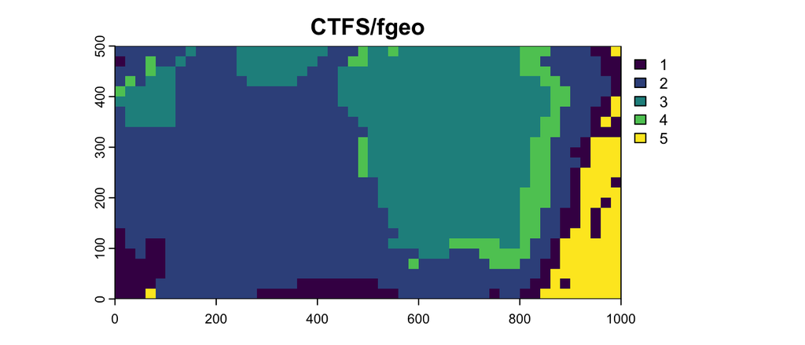

```r
terra::plot(habitat_to_raster(habitat.legacy), main = "CTFS/fgeo")
```

## 3.2 Standardized environmental classification

If one has more than the elevation profile, it is reasonable/advisable to use more (even all) environmental variables. This section shows how to cluster the quadrats using the PCA-based distances from terrain and soil.

Ward linkage groups quadrats in the PCA space. Cut the tree at the shared `habitat.k` from setup.

```r
linkage = "ward.D2"

cluster.tree <- hclust(environment.distance, method = linkage)
habitat.full.environment <- cutree(cluster.tree, k = habitat.k)

table(habitat.full.environment)
```

```
#> habitat.full.environment
#>   1   2   3   4   5
#>  34 211 509 339 157
```

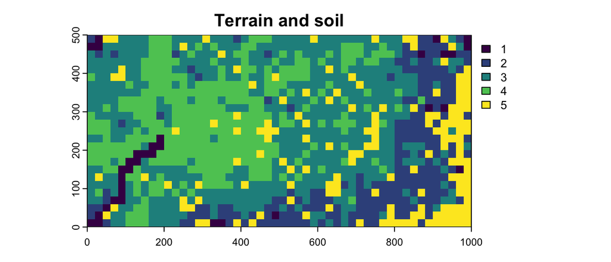

```r
terra::plot(habitat_to_raster(habitat.full.environment), main = "Terrain and soil")
```

## 3.3 Fuzzy environmental classes with FANNY

FANNY can use a distance matrix directly. Pass the same PCA distances to compare fuzzy and hard classifications in the same space. Each quadrat has membership scores that sum to one. The largest score gives its hard label. Keep the full matrix to see gradual boundaries.

```r
membership.exponent = 1.5  # Higher values make memberships more similar.

fuzzy.fit <- cluster::fanny(environment.distance, k = habitat.k, diss = TRUE,
    memb.exp = membership.exponent, maxit = 500, tol = 1e-8)

habitat.fanny <- setNames(fuzzy.fit$clustering, rownames(environment))
membership.fanny <- fuzzy.fit$membership
rownames(membership.fanny) <- rownames(environment)

fuzzy.fit$convergence
```

```
#> iterations  converged      maxit
#>        153          1        500
```

```r
table(habitat.fanny)
```

```
#> habitat.fanny
#>   1   2   3   4   5
#> 293 182 171 366 238
```

```r
summary(apply(membership.fanny, 1, max))
```

```
#>    Min. 1st Qu.  Median    Mean 3rd Qu.    Max.
#>  0.2036  0.2859  0.3309  0.3483  0.3793  0.6799
```

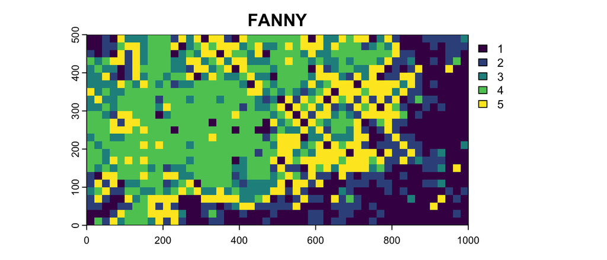

```r
terra::plot(habitat_to_raster(habitat.fanny), main = "FANNY")
```

Check convergence and the number of hard habitats. If memberships are nearly equal everywhere or some hard classes disappear, try a lower `membership.exponent` or a smaller `habitat.k`.

# 4 Floristically-informed classifications

These techniques use floristic composition to find environmental differences that matter for the sampled community. Choose composition data that match your ecological question.

## 4.1 Conditional inference tree

A tree splits the quadrats into groups by environmental rules, such as an elevation threshold. Su et al. (2010) used a multivariate regression tree (De’ath, 2002) to define seven habitats from tree composition and microtopography at Fushan, Taiwan. Here `ctree()` uses conditional tests to choose variables and splits (Hothorn et al., 2006). The original soil and terrain columns keep the thresholds in their measured units. The stopping rules below yield five terminal groups for these BCI data.

```r
tree.columns = names(environment)
minimum.occupied.quadrats = 10L
minimum.node.size = 50L
maximum.depth = 4L
split.criterion = 0.99
test.statistic = "quadratic"
split.statistic = "maximum"
tree.seed = 20261120

stopifnot(identical(rownames(environment), rownames(composition)))
species.keep <- colSums(composition > 0) >= minimum.occupied.quadrats
community <- composition[, species.keep, drop = FALSE]
training.rows <- rowSums(community) > 0

stopifnot(ncol(community) >= 2, any(training.rows))

# Hellinger transformation of the retained species' relative abundances.
community <- community[training.rows, , drop = FALSE]
community.hel <- sqrt(community / rowSums(community))
environment.tree <- environment[, tree.columns, drop = FALSE]
stopifnot(all(is.finite(as.matrix(environment.tree))))

# Join response and predictor columns and build the native tree formula.
floristic.data <- data.frame(community.hel, environment.tree[training.rows, , drop = FALSE])
response.names <- names(floristic.data)[seq_len(ncol(community.hel))]
predictor.names <- tail(names(floristic.data), ncol(environment.tree))
floristic.formula <- reformulate(predictor.names,
    response = paste(response.names, collapse = " + "))

set.seed(tree.seed)
floristic.tree <- partykit::ctree(floristic.formula, data = floristic.data,
    control = partykit::ctree_control(
        teststat = test.statistic, splitstat = split.statistic,
        mincriterion = split.criterion,
        minbucket = minimum.node.size, minsplit = 2L * minimum.node.size,
        maxdepth = maximum.depth
    ))

# Assign each quadrat to a terminal node using its environmental values.
names(environment.tree) <- predictor.names
habitat.ctree <- predict(floristic.tree, newdata = environment.tree, type = "node")
names(habitat.ctree) <- rownames(environment)

table(habitat.ctree)
```

```
#> habitat.ctree
#>   3   6   7   8   9
#>  50 613 278 253  56
```

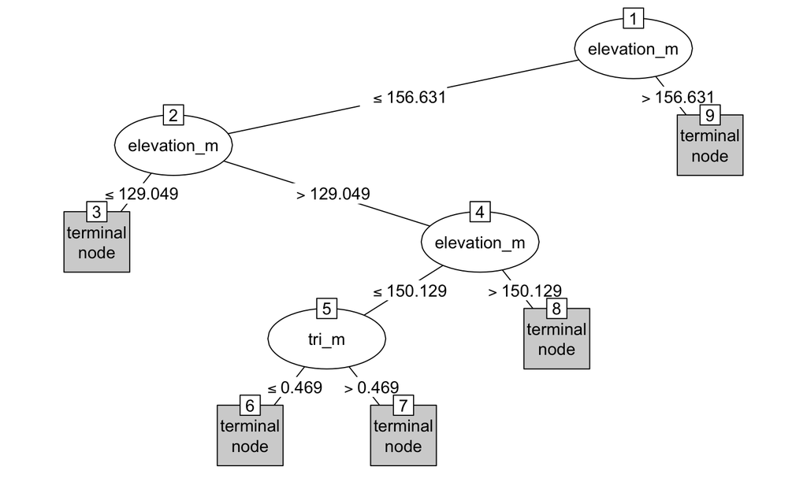

```r
plot(floristic.tree, type = "simple")
```

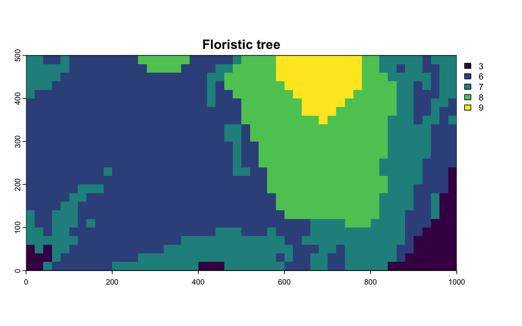

```r
terra::plot(habitat_to_raster(habitat.ctree), main = "Floristic tree")
```

The Hellinger transformation takes the square root of the proportion of each species in a quadrat, here among the retained species (Legendre and Gallagher, 2001). The tree uses differences in relative composition. A quadrat with no retained trees can still receive a label from its environmental values. The split tests guide the fit. Check predictions with held-out spatial blocks if you need evidence that the rules work at new locations (Roberts et al., 2017).

## 4.2 Optional probabilistic regions

Regions of Common Profile use a mixture model to relate composition to environment (Foster et al., 2013). The membership probabilities below use the observed flora and a small set of scaled terrain and soil variables. The map assigns each fitted quadrat to its most likely region.

**Start small.** Fits can be slow with many quadrats or species. This example uses a rectangle in the lower-left corner of the BCI plot and the most abundant species in that rectangle. Increase the two fractions in steps and check elapsed time and agreement among converged starts before fitting the full dataset.

This chunk runs when the optional package is installed. See the [package example](https://skiptoniam.github.io/ecomix/articles/RCP-example.html).

```r
p.quadrats.to.use = 0.1  # Proportion of quadrats to use, from the {0, 0} corner.
p.species.to.use = 0.05  # Proportion of species present in that rectangle.
rcp.columns = c("elevation_m", "slope_deg", "tpi_m", "soil_M3P", "soil_M3Ca")
number.starts = 10L
seed = 20261120

# remotes::install_github("skiptoniam/ecomix@17418626")
stopifnot(p.quadrats.to.use > 0, p.quadrats.to.use <= 1,
    p.species.to.use > 0, p.species.to.use <= 1)

# Scale both sides by the square root of the area fraction, then round to quadrats.
side.fraction <- sqrt(p.quadrats.to.use)
columns.to.use <- max(1L, round(side.fraction * length(unique(quadrats$xmin))))
rows.to.use <- max(1L, round(side.fraction * length(unique(quadrats$ymin))))
rcp.rows <- quadrats$xmin < plot.extent[1] + columns.to.use * quadrat.size &
    quadrats$ymin < plot.extent[3] + rows.to.use * quadrat.size
stopifnot(sum(rcp.rows) >= habitat.k)

# Rank species by their individual counts in the selected rectangle.
abundance <- sort(colSums(composition[rcp.rows, , drop = FALSE]), decreasing = TRUE)
abundance <- abundance[abundance > 0]
species.to.use <- max(1L, round(p.species.to.use * length(abundance)))
rcp.species <- names(head(abundance, species.to.use))
rcp.counts <- composition[rcp.rows, rcp.species, drop = FALSE]
rcp.environment <- as.data.frame(scale(environment[rcp.rows, rcp.columns, drop = FALSE]))
stopifnot(ncol(rcp.counts) > 0, all(is.finite(as.matrix(rcp.environment))))

rcp.data <- ecomix::make_mixture_data(
    species_data = rcp.counts,
    covariate_data = rcp.environment
)

# The constructor puts species columns first and environmental columns last.
response.names <- names(rcp.data)[seq_len(ncol(rcp.counts))]
predictor.names <- tail(names(rcp.data), ncol(rcp.environment))
rcp.formula <- reformulate(predictor.names,
    response = paste0("cbind(", paste(response.names, collapse = ", "), ")"))

set.seed(seed)
rcp.elapsed <- system.time(
    rcp.starts <- ecomix::regional_mix.multifit(
        rcp_formula = rcp.formula, species_formula = ~1,
        data = rcp.data, nRCP = habitat.k, family = "negative.binomial",
        nstart = number.starts, mc.cores = 1, titbits = FALSE,
        control = list(quiet = TRUE)
    )
)

log.likelihood <- sapply(rcp.starts$multiple_fits, function(fit)
    if(is.list(fit) && isTRUE(fit$conv == 0) && is.finite(fit$logl)) fit$logl else -Inf)
if(!any(is.finite(log.likelihood)))
    stop("No converged ecomix start. Inspect the input and fitting settings.")

regional.fit <- rcp.starts$multiple_fits[[which.max(log.likelihood)]]
posterior.rcp <- regional.fit$postProbs
stopifnot(nrow(posterior.rcp) == nrow(rcp.counts), ncol(posterior.rcp) == habitat.k,
    all(is.finite(posterior.rcp)))
rownames(posterior.rcp) <- rownames(rcp.counts)

# Leave quadrats outside the fitted rectangle unclassified.
habitat.ecomix <- setNames(rep(NA_integer_, nrow(quadrats)), quadrats$quadrat_id)
habitat.ecomix[rcp.rows] <- max.col(posterior.rcp, ties.method = "first")

c(quadrats = nrow(rcp.counts), species = ncol(rcp.counts),
    elapsed.seconds = unname(rcp.elapsed["elapsed"]))
round(log.likelihood, 1)
table(habitat.ecomix)
terra::plot(habitat_to_raster(habitat.ecomix), main = "ecomix, fitted rectangle")
```

# 5 Spatial smoothing

Nearby quadrats often have similar conditions. Smoothing can reduce isolated cells and make larger patches more contiguous and easier to see and interpret ecologically and in the field. However, spatial smoothing can also remove real features. For example, a stream habitat one quadrat wide can disappear when most neighbouring quadrats belong to the surrounding forest. Compare raw and smoothed maps, and think about whether they are realistic and useful, before choosing which one to use.

Choose a map in the first line below. The rest of the tutorial evaluates this one map. To compare alternative maps, repeat these sections for each one using the same quadrats and species data. Class sizes, environmental profiles and indicator species can help you choose a useful number of habitats. Choose your map before using species data to test associations with it.

```r
# Pick one habitat map
habitats <- habitat.full.environment
# habitats <- habitat.legacy
# habitats <- habitat.fanny
# habitats <- habitat.ctree
# habitats <- habitat.ecomix  # Fit the full plot before selecting this map.

use.smoothed.map = FALSE  # Set TRUE to use the filtered map below.

stopifnot(identical(names(habitats), quadrats$quadrat_id),
    identical(names(habitats), rownames(composition)), !anyNA(habitats))

habitats.original <- habitats
```

The filter uses each quadrat and the eight neighbours in its 3 × 3 window. It replaces the habitat with the most common label in that window. At the edge of the plot, it uses the cells within the plot. When several labels are equally common, the quadrat keeps its original label. All windows use the original map.

```r
original.map <- habitat_to_raster(habitats.original)
habitat.key <- terra::levels(original.map)[[1]]
habitat.labels <- habitat.key$habitat
original.codes <- terra::values(original.map, mat = FALSE)

# Each row gives the labels in one window. tabulate() skips NA at the edges.
windows <- terra::focalValues(original.map, w = 3)
smoothed.codes <- original.codes

for(i in seq_len(nrow(windows)))
{
    counts <- tabulate(windows[i, ], nbins = length(habitat.labels))
    most.common <- which(counts == max(counts))

    if(length(most.common) == 1L)
        smoothed.codes[i] <- most.common
}

# Back in quadrat order, even when the raster has a different cell order.
habitats.smoothed <- habitat.labels[smoothed.codes[quadrat.cells]]
names(habitats.smoothed) <- quadrats$quadrat_id
c(changed.quadrats = sum(habitats.smoothed != habitats.original),
    total.quadrats = length(habitats.original))
```

```
#> changed.quadrats   total.quadrats
#>              265             1250
```

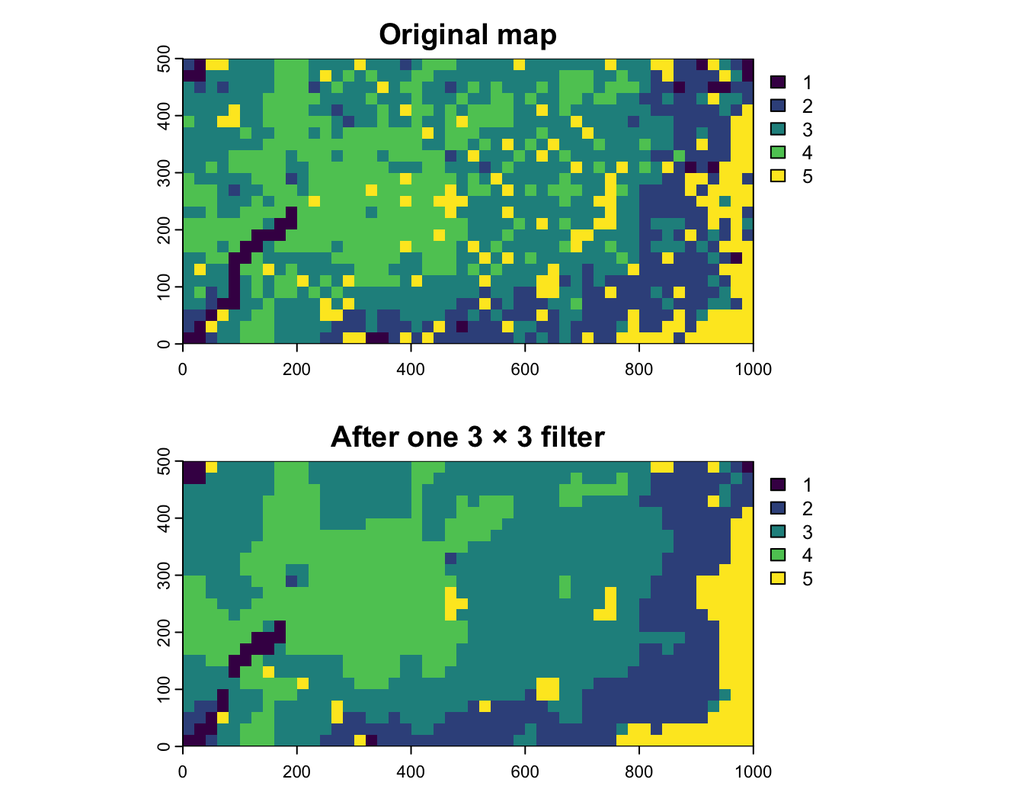

```r
smoothed.map <- original.map
terra::values(smoothed.map) <- smoothed.codes
levels(smoothed.map) <- habitat.key

old.par <- par(mfrow = c(2, 1))
terra::plot(original.map, main = "Original map", all_levels = TRUE)
terra::plot(smoothed.map, main = "After one 3 × 3 filter", all_levels = TRUE)
```

```r
par(old.par)

# Switch the map for the rest of the tutorial using the option above.
habitat.raster <- original.map

if(use.smoothed.map)
{
    habitats <- habitats.smoothed
    habitat.raster <- smoothed.map
}
```

Check how much area each habitat covers and which conditions it represents. The table gives class sizes and medians for selected terrain variables and Mehlich-3 phosphorus and calcium (mg/kg).

```r
profile.columns = c("elevation_m", "slope_deg", "tpi_m", "soil_M3P", "soil_M3Ca")

profiles <- aggregate(environment[, profile.columns, drop = FALSE],
    by = list(habitat = habitats), FUN = median)

sizes <- table(habitats)
profiles$quadrats <- as.integer(sizes[as.character(profiles$habitat)])
profiles$area_ha <- profiles$quadrats * quadrat.size^2 / 10000

knitr::kable(profiles, digits = 2, row.names = FALSE)
```

| habitat | elevation_m | slope_deg | tpi_m | soil_M3P | soil_M3Ca | quadrats | area_ha |
| --- | --- | --- | --- | --- | --- | --- | --- |
| 1 | 135.89 | 9.58 | -0.67 | 2.32 | 1365.99 | 34 | 1.36 |
| 2 | 140.38 | 8.94 | 0.04 | 2.24 | 1990.64 | 211 | 8.44 |
| 3 | 148.40 | 3.36 | 0.09 | 2.72 | 1425.35 | 509 | 20.36 |
| 4 | 143.52 | 2.85 | -0.01 | 2.85 | 893.61 | 339 | 13.56 |
| 5 | 138.81 | 4.92 | -0.01 | 2.92 | 2637.64 | 157 | 6.28 |

# 6 Indicator species

An indicator species is common across quadrats of a habitat and concentrated in that habitat. `indicspecies::strassoc()` describes both properties with `IndVal.g`. It uses the mean abundance in each habitat to measure concentration, so habitats can have different numbers of quadrats. The score is the square root of the product of concentration and the fraction of quadrats in the habitat where the species occurs (De Cáceres and Legendre, 2009).

```r
minimum.indicator.abundance = 1L  # Individuals in the whole plot.
number.to.show = 3L               # Species to show per habitat.

keep <- colSums(composition) >= minimum.indicator.abundance
stopifnot(any(keep), identical(names(habitats), rownames(composition)))

groups <- factor(habitats)
indicator.values <- indicspecies::strassoc(composition[, keep, drop = FALSE],
    cluster = as.integer(groups), func = "IndVal.g")
colnames(indicator.values) <- levels(groups)

# Keep the full score matrix. Show the highest positive scores for each habitat.
top.indicators <- vector("list", ncol(indicator.values))

for(h in seq_len(ncol(indicator.values)))
{
    scores <- indicator.values[, h]
    best <- order(scores, decreasing = TRUE)
    best <- head(best[scores[best] > 0], number.to.show)

    top.indicators[[h]] <- data.frame(habitat = rep(colnames(indicator.values)[h], length(best)),
        species = rownames(indicator.values)[best], indicator = scores[best])
}

top.indicators <- do.call(rbind, top.indicators)
knitr::kable(top.indicators, digits = 2, row.names = FALSE)
```

| habitat | species | indicator |
| --- | --- | --- |
| 1 | hassfl | 0.50 |
| 1 | cappfr | 0.49 |
| 1 | protte | 0.47 |
| 2 | drypst | 0.60 |
| 2 | ocotwh | 0.54 |
| 2 | poular | 0.54 |
| 3 | des2pa | 0.50 |
| 3 | alsebl | 0.50 |
| 3 | faraoc | 0.49 |
| 4 | cou2cu | 0.54 |
| 4 | faraoc | 0.51 |
| 4 | mourmy | 0.50 |
| 5 | gar2in | 0.49 |
| 5 | protte | 0.48 |
| 5 | tri2tu | 0.47 |

Use the scores to describe each habitat, including habitats fitted with these same species. An independent evaluation requires other observations. `indicspecies::multipatt()` can also examine combinations of habitats (De Cáceres et al., 2010).

# 7 Species–habitat associations with torus translations

Harms et al. (2001) moved the habitat map to assess species associations at BCI. Here `translate_around_torus()` moves the trees together and keeps the quadrats and their habitat labels fixed. Trees that cross one edge of the rectangle enter from the opposite edge. Each shift keeps the tree pattern intact on the wrapped plot.

## 7.1 Set up an independent fixed-map analysis

Use the selected `habitats` vector, the aligned `composition` matrix and the matching `quadrats` table. The original `individuals` table must contain `x`, `y` and `species` for all eligible trees counted in the matrix. Use the bounds of the full rectangular `plot.extent`, with a habitat label for every quadrat.

Choose the map before assessing associations. If the same trees helped fit or choose the map, use the labels as descriptions of those trees. For an independent test, use data that played no part in choosing or fitting the map.

To use a saved map in a separate script, load the objects saved under Store results.

```r
path.to.fgeo2 = "/full/path/to/fgeo2"
map.file = "/full/path/to/habitat-map.rds"

map <- readRDS(map.file)
habitats <- map$habitats
composition <- map$composition
quadrats <- map$quadrats
individuals <- map$individuals
plot.extent <- map$plot.extent
```

## 7.2 Check a small rectangle by hand

Put two 20 × 20 m quadrats side by side in a 40 × 20 m rectangle. Two trees of species A are in the left quadrat at (5, 5) and (8, 15). Two trees of species B are in the right quadrat at (25, 5) and (28, 15). A shift of 20 m in x puts A in the right quadrat and B in the left. For species A in the left habitat, the observed relative density is 2/2 = 1. After the shift it is 0/2 = 0.

## 7.3 Specify the statistic

Harms et al. (2001) and the legacy `tt_test()` use relative stem density. For each species and habitat, divide the species count by the total count of all species in that habitat. Here we count individuals using one record per tree. The abundance cutoff selects the species to report. All eligible trees contribute to the habitat totals.

`OBS` is the observed share and `EXP` holds the shares from 999 shifts, each calculated using its own habitat total. The score `mean(EXP > OBS)` is the fraction of shifted shares above the observed share. A habitat needs at least one tree for the share to be defined.

```r
nsim = 999L
torus.seed = 123L
minimum.abundance = 50L  # Minimum number of individuals of a species in the plot.
tail.cutoff = 0.025      # Proportion in each tail used to assign a label.

stopifnot(nsim >= 1L, nsim == floor(nsim), tail.cutoff > 0, tail.cutoff < 0.5)
source(file.path(path.to.fgeo2, "03_spatial/R/new/spatial-null-models.R"))
```

## 7.4 Align the map, counts and points

Use the quadrat edges to assign trees after each shift. A tree on an internal edge belongs to the quadrat to its right or above, as in the data preparation.

**Align the grid and check that the coordinates reproduce the counts**

```r
stopifnot(identical(rownames(composition), quadrats$quadrat_id),
    identical(names(habitats), quadrats$quadrat_id), !anyNA(habitats))

# Map each grid position to its row in the quadrat table.
x.edges <- sort(unique(c(quadrats$xmin, quadrats$xmax)))
y.edges <- sort(unique(c(quadrats$ymin, quadrats$ymax)))
nx <- length(x.edges) - 1L
ny <- length(y.edges) - 1L

qx <- match(quadrats$xmin, x.edges)
qy <- match(quadrats$ymin, y.edges)
grid.cells <- cbind(qy, qx)

stopifnot(nrow(quadrats) == nx * ny, !anyDuplicated(grid.cells),
    all(quadrats$xmax == x.edges[qx + 1L]),
    all(quadrats$ymax == y.edges[qy + 1L]),
    all(c(range(x.edges), range(y.edges)) == plot.extent))

grid.rows <- matrix(NA_integer_, nrow = ny, ncol = nx)
grid.rows[grid.cells] <- seq_len(nrow(quadrats))

# Check that the observed coordinates give the same quadrat counts.
coordinates <- as.matrix(individuals[, c("x", "y")])
species.index <- match(individuals$species, colnames(composition))

ix <- findInterval(coordinates[, 1], x.edges, rightmost.closed = TRUE)
iy <- findInterval(coordinates[, 2], y.edges, rightmost.closed = TRUE)
stopifnot(all(ix >= 1L & ix <= nx), all(iy >= 1L & iy <= ny), !anyNA(species.index))

quadrat.index <- grid.rows[cbind(iy, ix)]
count.index <- quadrat.index + (species.index - 1L) * nrow(quadrats)
point.counts <- matrix(tabulate(count.index, nbins = length(composition)),
    nrow = nrow(quadrats))

if(!all(point.counts == composition))
    stop("The coordinates and composition matrix give different quadrat counts.")

# Select the species to report.
focal.species <- colnames(composition)[colSums(composition) >= minimum.abundance]
stopifnot(length(focal.species) > 0)

groups <- factor(habitats)
habitat.index <- as.integer(groups)
counts.by.habitat <- rowsum(composition, habitat.index)
habitat.total <- rowSums(counts.by.habitat)

if(any(habitat.total == 0L))
    stop("Relative density is undefined for a habitat with no observed trees.")

# Divide each habitat row by its total across all species.
observed <- counts.by.habitat[, focal.species, drop = FALSE] / habitat.total
rownames(observed) <- levels(groups)

focal.index <- match(individuals$species, focal.species)
keep <- !is.na(focal.index)
focal.index <- focal.index[keep]
```

## 7.5 Shift the trees

Generate all 999 shifts in one call. Each column of the two coordinate matrices gives one shifted tree pattern. The matrices use about 3.8 GB for this BCI example. Use each shift’s habitat totals to calculate the relative densities and store them by habitat, species and shift.

```r
torus.mins <- plot.extent[c(1, 3)]
torus.maxs <- plot.extent[c(2, 4)]

set.seed(torus.seed)
shifted <- translate_around_torus(coordinates,
    mins = torus.mins, maxs = torus.maxs, nsim = nsim)

expected <- array(NA_real_, dim = c(dim(observed), nsim),
    dimnames = c(dimnames(observed), list(NULL)))

# Read each pair of coordinate columns and count trees by habitat.
for(b in seq_len(nsim))
{
    ix <- findInterval(shifted[[1]][, b], x.edges, rightmost.closed = TRUE)
    iy <- findInterval(shifted[[2]][, b], y.edges, rightmost.closed = TRUE)
    quadrat.index <- grid.rows[cbind(iy, ix)]
    shifted.habitat <- habitat.index[quadrat.index]

    habitat.total <- tabulate(shifted.habitat, nbins = nrow(observed))
    if(any(habitat.total == 0L))
        stop("Relative density is undefined for a shifted habitat with no trees.")

    # Each focal species has one set of slots, one slot per habitat.
    count.index <- shifted.habitat[keep] + (focal.index - 1L) * nrow(observed)
    focal.counts <- matrix(tabulate(count.index, nbins = length(observed)),
        nrow = nrow(observed))

    expected[, , b] <- focal.counts / habitat.total
}
```

## 7.6 Summarize the associations

At the 2.5% tail cutoff, the association is positive if at least 97.5% of the shifted shares are below the observed share. It is negative if at least 97.5% are above. Otherwise it is neutral. Equal shares count toward neither tail.

```r
association <- expand.grid(habitat = rownames(observed), species = colnames(observed),
    KEEP.OUT.ATTRS = FALSE, stringsAsFactors = FALSE)

association$observed <- as.vector(observed)
association$proportion.above <- NA_real_
association$association <- "neutral"

for(i in seq_len(nrow(association)))
{
    obs.share <- association$observed[i]
    exp.shares <- expected[association$habitat[i], association$species[i], ]

    above <- mean(exp.shares > obs.share)
    below <- mean(exp.shares < obs.share)
    association$proportion.above[i] <- above

    if(below >= 1 - tail.cutoff)
        association$association[i] <- "positive"
    if(above >= 1 - tail.cutoff)
        association$association[i] <- "negative"
}

table(association$association)
```

```
#>
#> negative  neutral positive
#>       74      812       84
```

We are doing many comparisons and you may be tempted to apply Bonferroni-like corrections. Don’t do that. Species are strongly correlated with each other. Zambrano, Arellano, et al. (2022) contains an example on how to choose sensible thresholds for siginficance in cases of many correlated tests in species-rich communities.

## 7.7 Inspect two example null distributions

The vertical line shows the observed relative density. The histogram shows the relative densities from the shifts for the same species and habitat. Use the table to find the score and label for any pair.

```r
example.species = "ouralu"  # Ouratea lucens in the BCI species table.
example.habitats = NULL     # Or select two labels, for example c("2", "4").

examples <- subset(association, species == example.species)
if(!is.null(example.habitats))
    examples <- subset(examples, habitat %in% example.habitats)

examples <- head(examples, 2L)
if(nrow(examples) == 0L)
    stop("Choose a species and habitat labels from the association table.")

knitr::kable(examples, digits = 3, row.names = FALSE)
```

| habitat | species | observed | proportion.above | association |
| --- | --- | --- | --- | --- |
| 1 | ouralu | 0.006 | 0.279 | neutral |
| 2 | ouralu | 0.003 | 0.980 | negative |

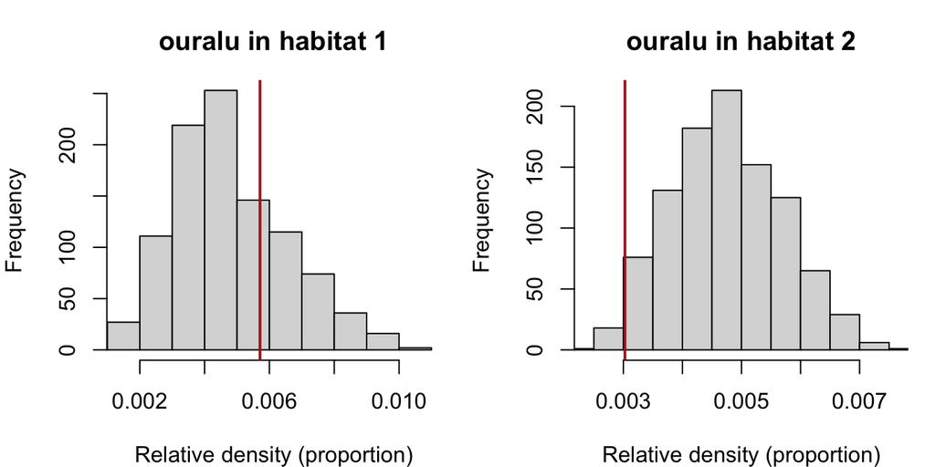

```r
old.par <- par(mfrow = c(1, nrow(examples)), mar = c(4, 4, 3, 1))

for(i in seq_len(nrow(examples)))
{
    exp.shares <- expected[examples$habitat[i], examples$species[i], ]
    obs.share <- examples$observed[i]

    hist(exp.shares, xlim = range(c(exp.shares, obs.share)), col = "grey85",
        main = paste(examples$species[i], "in habitat", examples$habitat[i]),
        xlab = "Relative density (proportion)")
    abline(v = obs.share, col = "firebrick", lwd = 2)
}
```

```r
par(old.par)
```

# 8 Compare habitat maps

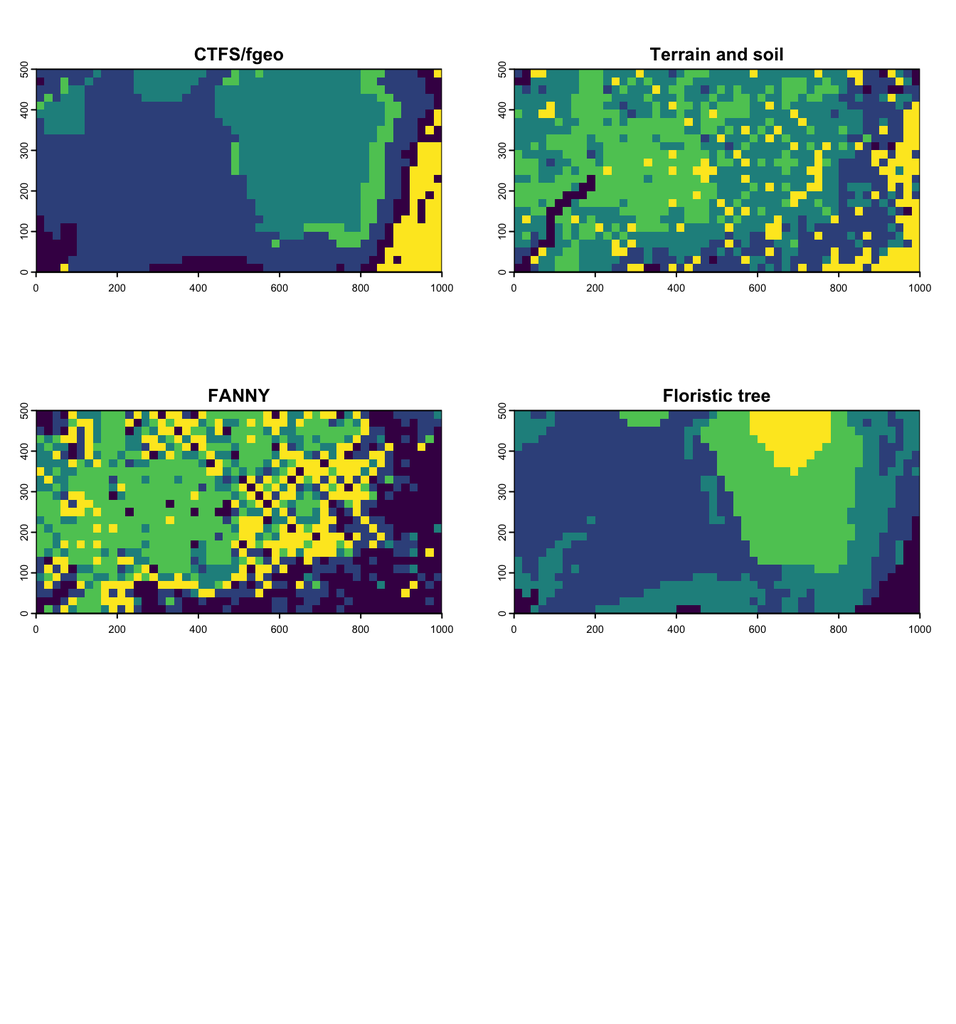

```r
habitat.maps <- list(
    "CTFS/fgeo" = habitat.legacy,
    "Terrain and soil" = habitat.full.environment,
    "FANNY" = habitat.fanny,
    "Floristic tree" = habitat.ctree
)

if(exists("habitat.ecomix"))
    habitat.maps$ecomix <- habitat.ecomix

old.par <- par(mfrow = c(3, 2), mar = c(2, 2, 2, 1))
for(method in names(habitat.maps))
    terra::plot(habitat_to_raster(habitat.maps[[method]]), main = method, legend = FALSE)
par(old.par)
```

Compare each pair of maps where both have labels. Among pairs of quadrats placed in the same habitat by either map, agreement is the fraction placed together by both. A value of 1 means identical groupings, regardless of the habitat numbers.

```r
map.pairs <- combn(names(habitat.maps), 2)
agreement <- data.frame(map.1 = map.pairs[1, ], map.2 = map.pairs[2, ],
    quadrats = NA_integer_, agreement = NA_real_)

for(i in seq_len(ncol(map.pairs)))
{
    labels.1 <- habitat.maps[[map.pairs[1, i]]]
    labels.2 <- habitat.maps[[map.pairs[2, i]]]
    overlap <- table(labels.1, labels.2)

    # A group of n quadrats contains choose(n, 2) pairs.
    together.both <- sum(choose(overlap, 2))
    together.either <- sum(choose(rowSums(overlap), 2)) +
        sum(choose(colSums(overlap), 2)) - together.both

    agreement$quadrats[i] <- sum(overlap)
    if(together.either > 0)
        agreement$agreement[i] <- together.both / together.either
}

knitr::kable(agreement, digits = 2, row.names = FALSE)
```

| map.1 | map.2 | quadrats | agreement |
| --- | --- | --- | --- |
| CTFS/fgeo | Terrain and soil | 1250 | 0.25 |
| CTFS/fgeo | FANNY | 1250 | 0.20 |
| CTFS/fgeo | Floristic tree | 1250 | 0.44 |
| Terrain and soil | FANNY | 1250 | 0.39 |
| Terrain and soil | Floristic tree | 1250 | 0.24 |
| FANNY | Floristic tree | 1250 | 0.21 |

It is surprising, or maybe not, the level of agreement between the legacy CTFS/fgeo classification, which only looks at three environmental variables, and the floristically-informed map, which uses all environmental variables and the entire floristic composition. This means that those few topographical variables encode much of what is relevant for this tree community in particular.

# 9 Store results

Save the selected map as a categorical `terra` raster. The GeoTIFF stores integer codes and the key records the corresponding habitat labels. Keep any GeoTIFF sidecars with the raster. The R file stores all methods’ quadrat labels and the inputs for the selected map.

```r
output.dir = file.path(tempdir(), "fgeo2-habitats")
# output.dir = "/full/path/to/outputs"  # Use a permanent folder to keep the files.
overwrite = FALSE

dir.create(output.dir, recursive = TRUE, showWarnings = FALSE)

terra::writeRaster(habitat.raster, file.path(output.dir, "habitat-map.tif"),
    datatype = "INT4S", overwrite = overwrite)
write.csv(habitat.key, file.path(output.dir, "habitat-key.csv"), row.names = FALSE)

map <- list(habitats = habitats, habitat.maps = habitat.maps,
    quadrats = quadrats, environment = environment,
    composition = composition, individuals = individuals, plot.extent = plot.extent)

saveRDS(map, file.path(output.dir, "habitat-map.rds"))
```

If you ran the indicator or torus analysis, save the results you need. Keep `membership.fanny` or the region probabilities if you use those methods. They have one row per quadrat and one column per habitat.

```r
# Run the lines for the analyses you used.
write.csv(indicator.values, file.path(output.dir, "indicator-scores.csv"))
write.csv(association, file.path(output.dir, "species-habitat-associations.csv"),
    row.names = FALSE)

saveRDS(list(relative.density = expected, nsim = nsim,
    seed = torus.seed, tail.cutoff = tail.cutoff),
    file.path(output.dir, "torus-relative-density.rds"))
```

# 10 References

- Comita, L. S., Condit, R. & Hubbell, S. P. (2007). Developmental changes in habitat associations of tropical trees. *Journal of Ecology*, 95, 482–492. [doi:10.1111/j.1365-2745.2007.01229.x](https://doi.org/10.1111/j.1365-2745.2007.01229.x).
- Condit, R., Pérez, R., Aguilar, S., Lao, S., Foster, R. B. & Hubbell, S. P. (2019). Complete data from the Barro Colorado 50-ha plot: 423617 trees, 35 years. *Dryad*. [doi:10.15146/5xcp-0d46](https://doi.org/10.15146/5xcp-0d46).
- De’ath, G. (2002). Multivariate regression trees: a new technique for modeling species–environment relationships. *Ecology*, 83, 1105–1117. [doi:10.1890/0012-9658(2002)083[1105:MRTANT]2.0.CO;2](https://doi.org/10.1890/0012-9658%282002%29083%5B1105%3AMRTANT%5D2.0.CO%3B2).
- De Cáceres, M. & Legendre, P. (2009). Associations between species and groups of sites: indices and statistical inference. *Ecology*, 90, 3566–3574. [doi:10.1890/08-1823.1](https://doi.org/10.1890/08-1823.1).
- De Cáceres, M., Legendre, P. & Moretti, M. (2010). Improving indicator species analysis by combining groups of sites. *Oikos*, 119, 1674–1684. [doi:10.1111/j.1600-0706.2010.18334.x](https://doi.org/10.1111/j.1600-0706.2010.18334.x).
- Foster, S. D., Givens, G. H., Dornan, G. J., Dunstan, P. K. & Darnell, R. (2013). Modelling biological regions from multi-species and environmental data. *Environmetrics*, 24, 489–499. [doi:10.1002/env.2245](https://doi.org/10.1002/env.2245).
- Gunatilleke, C. V. S., Gunatilleke, I. A. U. N., Esufali, S., Harms, K. E., Ashton, P. M. S., Burslem, D. F. R. P. & Ashton, P. S. (2006). Species–habitat associations in a Sri Lankan dipterocarp forest. *Journal of Tropical Ecology*, 22, 371–384. [doi:10.1017/S0266467406003282](https://doi.org/10.1017/S0266467406003282).
- Harms, K. E., Condit, R., Hubbell, S. P. & Foster, R. B. (2001). Habitat associations of trees and shrubs in a 50-ha neotropical forest plot. *Journal of Ecology*, 89, 947–959. [doi:10.1111/j.1365-2745.2001.00615.x](https://doi.org/10.1111/j.1365-2745.2001.00615.x).
- Hothorn, T., Hornik, K. & Zeileis, A. (2006). Unbiased recursive partitioning: a conditional inference framework. *Journal of Computational and Graphical Statistics*, 15, 651–674. [doi:10.1198/106186006X133933](https://doi.org/10.1198/106186006X133933).
- Kaufman, L. & Rousseeuw, P. J. (1990). *Finding Groups in Data: An Introduction to Cluster Analysis*. Wiley. Algorithm reference supplied by `cluster`.
- Legendre, P. & Gallagher, E. D. (2001). Ecologically meaningful transformations for ordination of species data. *Oecologia*, 129, 271–280. [doi:10.1007/s004420100716](https://doi.org/10.1007/s004420100716).
- Peres-Neto, P. R., Jackson, D. A. & Somers, K. M. (2005). How many principal components? Stopping rules for determining the number of non-trivial axes revisited. *Computational Statistics & Data Analysis*, 49, 974–997. [doi:10.1016/j.csda.2004.06.015](https://doi.org/10.1016/j.csda.2004.06.015).
- Roberts, D. R., et al. (2017). Cross-validation strategies for data with temporal, spatial, hierarchical, or phylogenetic structure. *Ecography*, 40, 913–929. [doi:10.1111/ecog.02881](https://doi.org/10.1111/ecog.02881).
- Su, S.-H., Hsieh, C.-F., Chang-Yang, C.-H., Lu, C.-L. & Guan, B. T. (2010). Micro-topographic differentiation of the tree species composition in a subtropical submontane rainforest in northeastern Taiwan. *Taiwan Journal of Forest Science*, 25, 63–80. [Full text](https://ws.tfri.gov.tw/001/Upload/OldFile/files/25-1_07.pdf).
- Wolf, J. A., Hubbell, S. P., Fricker, G. A. & Turner, B. L. (2015). Geospatial observations on tropical forest surface soil chemistry. *Ecology*, 96, 2313. [doi:10.1890/15-0558.1](https://doi.org/10.1890/15-0558.1).
- Yamada, T., Noor, N. S. M. & Okuda, T. (2010). Habitat association of trees in a 50-ha Malaysian rain forest plot. *Tropics*, 19, 1–8. [doi:10.3759/tropics.19.1](https://doi.org/10.3759/tropics.19.1).
- Zambrano, J., Arellano, G., Swenson, N. G., Staniczenko, P. P. A., Thompson, J. & Fagan, W. F. (2022). Analyses of three-dimensional species associations reveal departures from neutrality in a tropical forest. *Ecology*, 103, e3681. [doi:10.1002/ecy.3681](https://doi.org/10.1002/ecy.3681).